# Two Faces of the Moon

Pink Floyd’s Evolution Before and After Syd Barrett

Author

Sepehr Akbari

Published

December 11, 2024

Research Focus

How did Syd Barrett’s departure shape the evolution of Pink Floyd’s sound, as reflected in key musical features such as energy, mood, and instrumentation, and what does this reveal about the band’s artistic transformation?

## Setup

```
packages & libraries
```

```r
library(dotenv) # for loading environment variables
library(gt) # for creating neater tables
library(spotifyr) # for accessing Spotify API
library(tidyverse) # for data manipulation and visualization
```

```
API setup
```

```r
dotenv::load_dot_env()

Sys.setenv(SPOTIFY_CLIENT_ID = Sys.getenv("SPOTIFY_CLIENT_ID"))
Sys.setenv(SPOTIFY_CLIENT_SECRET = Sys.getenv("SPOTIFY_CLIENT_SECRET"))

access_token <- get_spotify_access_token()
```

```
loading data
```

```r
pink_floyd <- get_artist_audio_features("Pink Floyd")
```

## Introduction

For rock enthusiasts, Pink Floyd needs no introduction—nor does their legendary guitarist Syd Barrett, whose creative genius shaped the band’s early sound. Barrett’s departure, however, was more than celebrity drama; it marked one of rock’s most defining moments, transforming Pink Floyd from a psychedelic rock band into a progressive rock powerhouse.

**Null Hypothesis ($H_0$):** There is no significant difference in energy, valence, and instrumentalness between Pink Floyd’s pre- and post-Barrett eras.

**Alternative Hypothesis ($H_1$):** There is a significant difference in energy, valence, and instrumentalness between Pink Floyd’s pre- and post-Barrett eras.

## Data Exploration

First, we clean the data to include only original studio albums, excluding remixes, live concerts, and compilations. The dataset is further limited to albums released before Roger Waters left the band in 1985, marking the group’s breakup. Unnecessary columns are also removed to focus on relevant musical features for analysis.

```
cleaning data
```

```r
albums <- c("The Piper at the Gates of Dawn",
            "A Saucerful of Secrets",
            "More",
            "Ummagumma",
            "Atom Heart Mother",
            "Meddle",
            "Obscured by Clouds",
            "The Dark Side of the Moon",
            "Wish You Were Here",
            "Animals",
            "The Wall",
            "The Final Cut",
            "A Momentary Lapse of Reason",
            "The Division Bell",
            "The Endless River")

pink_floyd <- pink_floyd %>%
  filter(album_name %in% albums) %>%
  select("album_name",
         "album_release_year",
         "track_name",
         "duration_ms",
         "explicit",
         danceability:tempo,
         key_name:key_mode) %>%
  filter(album_release_year <= 1985)
```

Syd Barrett officially left the band in 1968, but *More (1969)* is often seen as an album heavily influenced by Barrett’s style, even though he did not actively contribute to it. On the other hand, *Ummagumma (1969)* is widely regarded as an experimental project rather than a cohesive Pink Floyd album, as each band member contributed their own solo works. For these reasons, *More* is included in the pre-Barrett era, while *Ummagumma* is excluded from the analysis, to ensure our conclusion is as accurate as possible.

```
defining eras
```

```r
pre_barrett_albums <- c("The Piper at the Gates of Dawn",
                        "A Saucerful of Secrets",
                        "More")

pink_floyd <- pink_floyd %>%
  filter(album_name != "Ummagumma") %>%
  mutate(era = case_when(
    album_name %in% pre_barrett_albums ~ "Pre-Barrett",
    TRUE ~ "Post-Barrett"
  ))
```

Before starting to analyze `energy`, `valence`, and `instrumentalness`, let’s calculate their average for each album. As Pink Floyd’s concept albums tell cohesive stories, these averages provide a clearer view of their musical evolution over time.

```
album averages
```

```r
pink_floyd_albums <- pink_floyd %>%
  group_by(album_name, album_release_year, era) %>%
  summarize(
    avg_energy = mean(energy),
    avg_valence = mean(valence),
    avg_instrumentalness = mean(instrumentalness),
  )
```

## Analysis

```r
pink_floyd_albums_tidy <- pink_floyd_albums %>%
  pivot_longer(
    cols = starts_with("avg"),
    names_to = "feature",
    values_to = "value"
  )
```

[figure not shown]

```r
ggplot(
  pink_floyd_albums_tidy,
  aes(x = album_release_year,
      y = value,
      color = feature,
      group = feature)
) +
  geom_point(size = 2) +
  geom_smooth(se = FALSE) +
  geom_vline(
    aes(xintercept = 1969),
    color = "#020307",
    linewidth = 0.75,
    alpha = 0.75
  ) +
  annotate("text",
           x = 1969 + 1.33,
           y = 0.6 + 0.01,
           label = "—— Barrett Leaves",
           color = "#020307",
           alpha = 0.85) +
  labs(
    title = "Pink Floyd's stats Over Time",
    x = "Release Year",
    y = NULL,
    color = NULL
  ) +
  theme_minimal() +
  theme(legend.position = "top") +
  scale_color_brewer(palette = "Dark2",
                     labels = c("Energy", "Valence", "Instrumentalness"))
```

### Energy

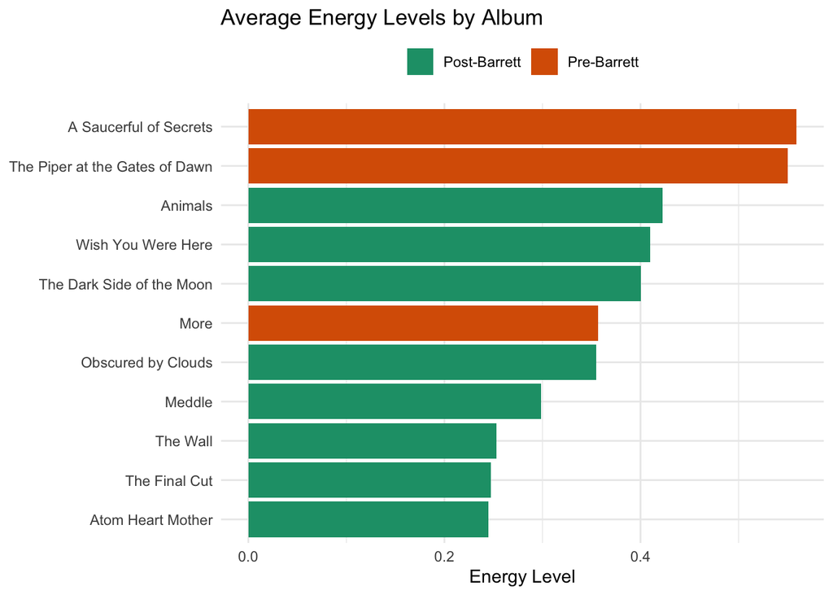

```r
ggplot(
  pink_floyd_albums,
  aes(x = avg_energy,
      y = reorder(album_name, avg_energy),
      fill = era)
) +
  geom_col() +
  labs(
    title = "Average Energy Levels by Album",
    x = "Energy Level",
    y = NULL,
    fill = NULL
  ) +
  theme_minimal() +
  scale_fill_brewer(palette = "Dark2") +
  theme(legend.position = "top")
```

### Valence

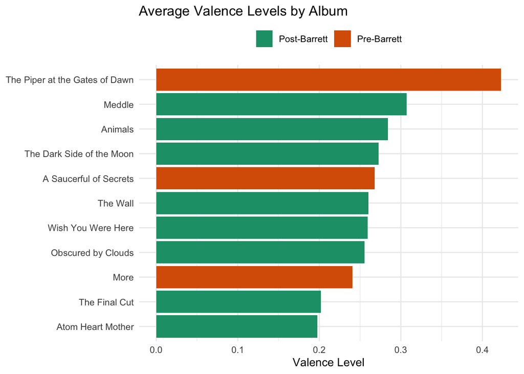

```r
ggplot(
  pink_floyd_albums,
  aes(x = avg_valence,
      y = reorder(album_name, avg_valence),
      fill = era)
) +
  geom_col() +
  labs(
    title = "Average Valence Levels by Album",
    x = "Valence Level",
    y = NULL,
    fill = NULL
  ) +
  theme_minimal() +
  scale_fill_brewer(palette = "Dark2") +
  theme(legend.position = "top")
```

### Instrumentalness

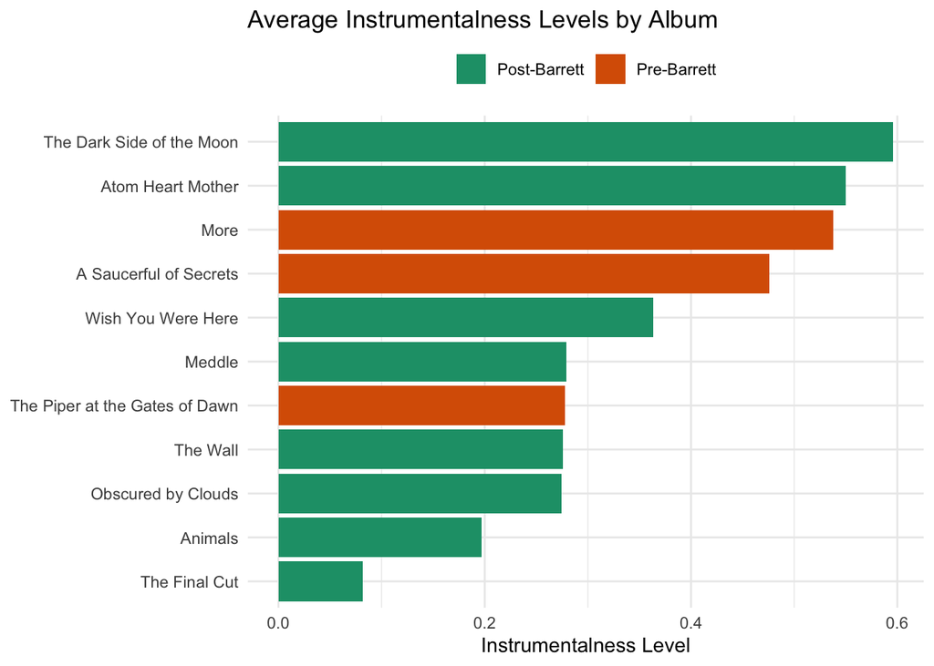

```r
ggplot(
  pink_floyd_albums,
  aes(x = avg_instrumentalness,
      y = reorder(album_name, avg_instrumentalness),
      fill = era)
) +
  geom_col() +
  labs(
    title = "Average Instrumentalness Levels by Album",
    x = "Instrumentalness Level",
    y = NULL,
    fill = NULL
  ) +
  theme_minimal() +
  scale_fill_brewer(palette = "Dark2") +
  theme(legend.position = "top")
```

### Overview

```r
pink_floyd_overview <- pink_floyd_albums %>%
  group_by(era) %>%
  summarize(
    avg_energy = mean(avg_energy),
    avg_valence = mean(avg_valence),
    avg_instrumentalness = mean(avg_instrumentalness)
  )

change_row <- pink_floyd_overview %>%
  summarize(
    era = "Change",
    avg_energy = diff(avg_energy),
    avg_valence = diff(avg_valence),
    avg_instrumentalness = diff(avg_instrumentalness)
  )

pink_floyd_overview <- bind_rows(pink_floyd_overview, change_row)
```

```r
pink_floyd_overview %>%
  gt() %>%
  tab_header(
    title = "Pink Floyd's Musical Evolution",
    subtitle = "Average Audio Features by Era"
  ) %>%
  cols_label(
    avg_energy = "Energy",
    avg_valence = "Valence",
    avg_instrumentalness = "Instrumentalness",
    era = ""
  ) %>%
  tab_options(
    column_labels.padding.horizontal = px(50),
    data_row.padding.horizontal = px(50)
  )
```

Pink Floyd's Musical Evolution

Average Audio Features by Era

|  | Energy | Valence | Instrumentalness |
| --- | --- | --- | --- |
| Post-Barrett | 0.3289537 | 0.25477192 | 0.3271780 |
| Pre-Barrett | 0.4886283 | 0.31040986 | 0.4304690 |
| Change | 0.1596746 | 0.05563793 | 0.1032909 |